# Lab 08 - GLMs in R: an introduction

dove V è la matrice diagonale con elementi
$$V_{ii} = \frac{1}{V(Y_i)}\left( \frac{d \mu}{d
\eta}\right)^{2}.$$
Per la distribuzione di Poisson con un legame logaritmico ($\mu = \exp(\eta)$) si ha che:
$$V(Y_i) = \mu_i \quad e \quad
\frac{d \mu}{d \eta} = \frac{d exp(\eta)}{d \eta}$$
quindi si ha:
$$V_{ii} = \exp\{\beta_0 +
\beta_{i,1} x_{i,1} + \ldots + \beta_p x_{i,p}\}.$$
Se i valori di $\beta_j$ sono noti la matrice di vera varianza-covarianza per il modello risulta quindi essere:

```r
V <- diag(as.vector(exp(Xmat %*%beta_vals)))
(var_betas <- solve(t(Xmat) %*% V %*%Xmat))
```

```
##                            x_vals
##         0.000883724 -0.0001043910
## x_vals -0.000104391  0.0001383835
```

Cosa succede invece alle stime derivate dai dati simulati?

```r
var(rep_sim)
```

```
##               (Intercept)        x_vals
## (Intercept)  8.843849e-04 -9.262544e-05
## x_vals      -9.262544e-05  1.361113e-04
```

I valori derivati dalla simulazione risultano molto simili a quelli che ci si aspetta di trovare dai valori teorici.

L’ultima cosa da verificare è che la distribuzione degli stimatori sia normale (con media e varianza che abbiamo già visto essere quelli vicini a quelli che ci sti aseptta dai risultati teorici):

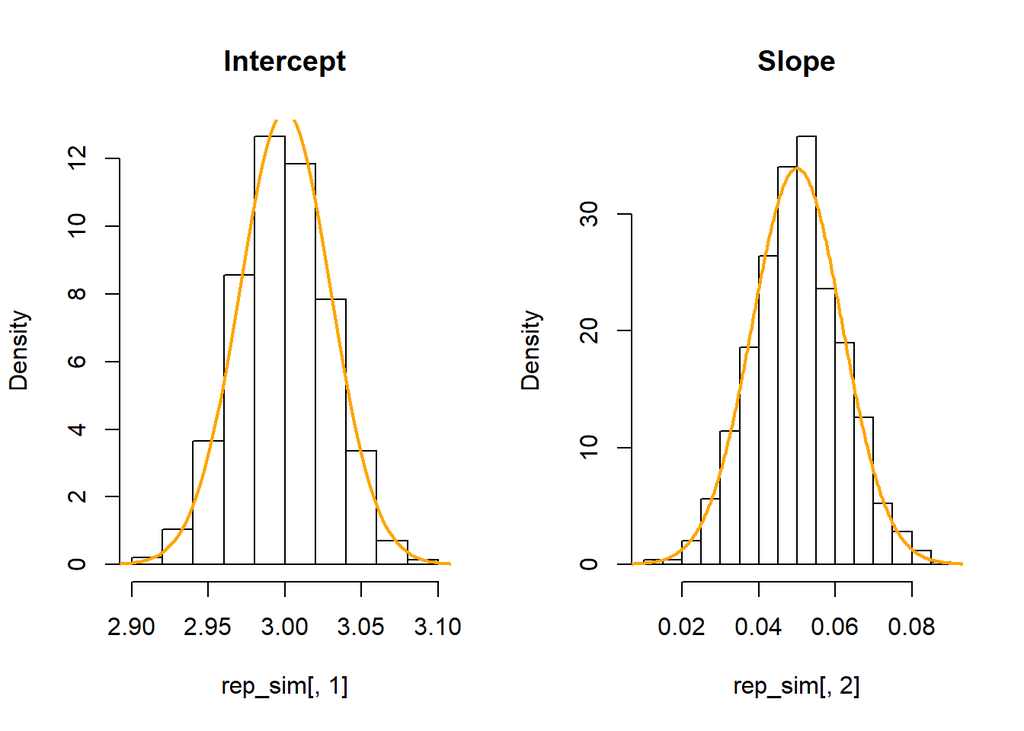

```r
par(mfrow=c(1,2))
hist(rep_sim[,1], freq = FALSE, col = NA, main = "Intercept")
lines(seq(2,4,by=0.0025),
      dnorm(seq(2,4,by=0.0025), beta_vals[1], sqrt(var_betas[1,1])),
      col="orange", lwd = 2)
hist(rep_sim[,2], freq = FALSE, col = NA, main = "Slope")
lines(seq(0,1,by=0.00025),
      dnorm(seq(0,1,by=0.00025), beta_vals[2], sqrt(var_betas[2,2])),
      col="orange", lwd = 2)
```

Gli istogrammi risultano simili alla distribuzione normali che ci si aspetta secondo i risultati teorici.

*Esercizio*: si può provare a vedere cosa succede quando cambia la numerosità campionaria; oppure quando cambia la vera funzione $\mu(x)$, in particolare quando prende valori abbastanza piccoli (ad esempio in un intervallo tra 0 e 4) o abbastanza grandi (ad esempio in un intervallo tra 70 e 90)

## Distribuzione Binomiale

Abbiamo visto cosa succede quando la distribuzione che genera i dati è una Poisson. Cosa succede quando usiamo una distribuzione binomiale? Possiamo innanzi tutto generare una vera funzione $p(x)$ usando la una funzione logistica:

```r
n <- 60
x_vals <- runif(n,0, 4)
true_coefs <- c(-1.5,2)
Xmat <- cbind(rep(1, n), x_vals)
range(Xmat %*% true_coefs)
```

```
## [1] -1.444412  6.497580
```

```r
range(exp(Xmat %*% true_coefs)/(1+exp(Xmat %*% true_coefs)))
```

```
## [1] 0.1908631 0.9984952
```

Possiamo ora generare dei dati da una variabile binomiale. Per ora ci concentriamo su delle distribuzioni in cui il numero di tentativi fatti per l’evento siano 200:

```r
sim_fit_coef <- function(n, X, size, pars){
  y_sim <- rbinom(n, size = size, exp(X %*% pars)/(1+exp(X %*% pars)))
  y_fail <- size - y_sim
  glm(cbind(y_sim, y_fail) ~ x_vals, family = binomial)$coefficients
}
sim_fit_coef(n=n, X = Xmat, size = 200, pars = true_coefs)
```

```
## (Intercept)      x_vals
##   -1.520981    2.039188
```

```r
NSIM <- 500; set.seed(5454)
rep_sim <- t(replicate(NSIM,
          sim_fit_coef(n=n, X = Xmat, size = 200, pars = true_coefs)))
colMeans(rep_sim)
```

```
## (Intercept)      x_vals
##   -1.502880    2.002921
```

```r
true_coefs
```

```
## [1] -1.5  2.0
```

Deriviamo delle stime non distorte, cioè recuperiamo in media il vero valore del parametro. Che variabilità c’è in questa stima? Dalla teoria ci si aspetterebbe di trovare una variabilità data da:

```r
V <- diag(as.vector(exp(Xmat %*% true_coefs)/((1+exp(Xmat %*% true_coefs))^2))*200)
(true_vcov <- solve(t(Xmat) %*% V %*% Xmat))
```

```
##                           x_vals
##         0.002757470 -0.001854647
## x_vals -0.001854647  0.001811513
```

mentre per le simulazioni troviamo:

```r
var(rep_sim)
```

```
##              (Intercept)       x_vals
## (Intercept)  0.002657281 -0.001767424
## x_vals      -0.001767424  0.001685992
```

Troviamo una buona corrispondenza tra i valori.

In generale, possiamo verificare che la distribuzione delle stime derivate dai dati simulati, corrisponde abbastanza bene alla disitrbuzione derivata dalla teoria:

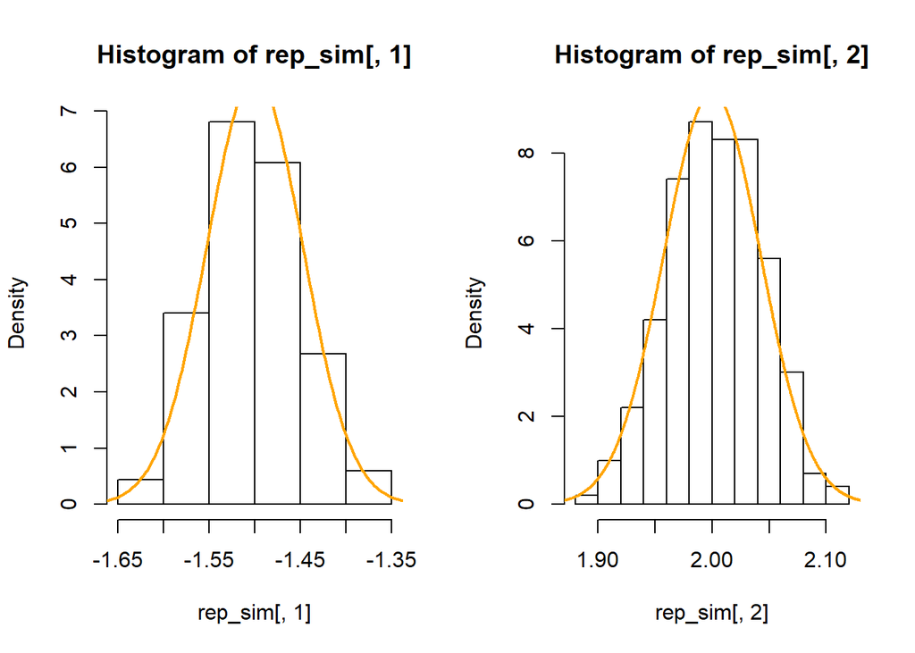

```r
par(mfrow=c(1,2))
hist(rep_sim[,1], freq = FALSE, col = NA)
lines(seq(-2,-1,by=0.0025),
      dnorm(seq(-2,-1,by=0.0025), true_coefs[1], sqrt(true_vcov[1,1])),
      col="orange", lwd = 2)
hist(rep_sim[,2], freq = FALSE, col = NA)
lines(seq(1.8,2.2,by=0.00025),
      dnorm(seq(1.8,2.2,by=0.00025),  true_coefs[2], sqrt(true_vcov[2,2])),
      col="orange", lwd = 2)
```

Cosa succede però se il numero di tentativi su cui si calcola il numero di successi diminuisce, per esempio a 5:

```r
NSIM <- 500; set.seed(5454)
rep_sim <- t(replicate(NSIM,
          sim_fit_coef(n=n, X = Xmat, size = 5, pars = true_coefs)))
colMeans(rep_sim)
```

```
## (Intercept)      x_vals
##   -1.535347    2.030553
```

```r
true_coefs
```

```
## [1] -1.5  2.0
```

```r
V <- diag(as.vector(exp(Xmat %*% true_coefs)/((1+exp(Xmat %*% true_coefs))^2))*5)
(true_vcov <- solve(t(Xmat) %*% V %*% Xmat))
```

```
##                         x_vals
##         0.11029879 -0.07418589
## x_vals -0.07418589  0.07246051
```

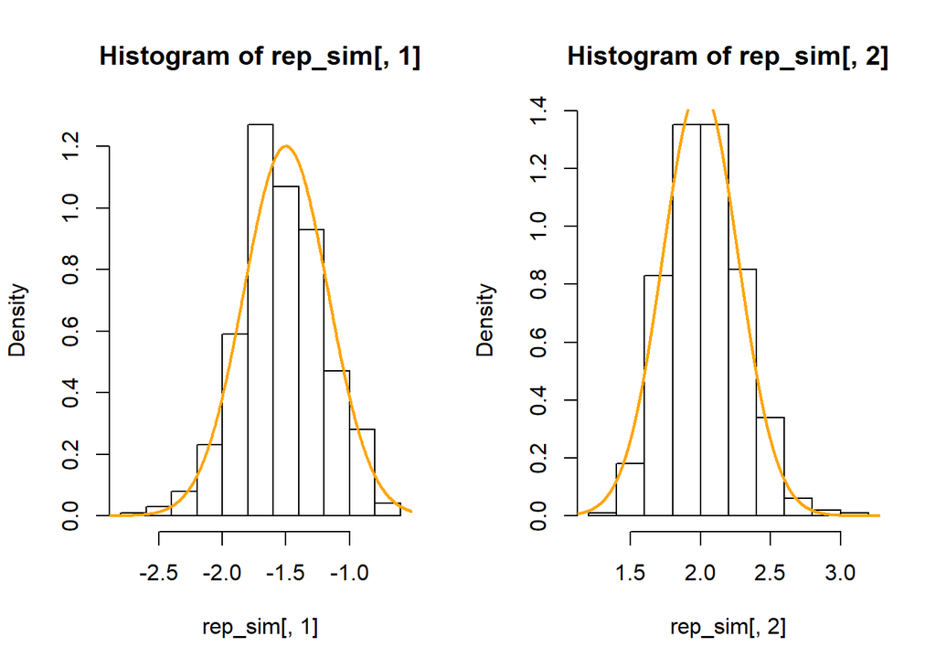

```r
par(mfrow=c(1,2))
hist(rep_sim[,1], freq = FALSE, col = NA)
lines(seq(-5,2,by=0.0025),
      dnorm(seq(-5,2,by=0.0025), true_coefs[1], sqrt(true_vcov[1,1])),
      col="orange", lwd = 2)
hist(rep_sim[,2], freq = FALSE, col = NA)
lines(seq(0,4,by=0.00025),
      dnorm(seq(0,4,by=0.00025),  true_coefs[2], sqrt(true_vcov[2,2])),
      col="orange", lwd = 2)
```

La precisione dell’approssimazione della normale diminuisce, gli istogrammi risultano un po’ asimmetrici (cosa succede quando i dati seguono una Bernoulli, cioè un Binomiale con un solo tentativo?). Una binomiale basata su molti tentativi viene approssimata abbastanza bene da una gaussiana. In generale, più la vera distribuzione dei dati è simmetrica, meglio la distribuzione degli stimatori viene approssimato dalla normale.